# How to analysis changes in NBA games’ playing style by analyzing the changes of stats of players in NBA

Getong Zhong

2022-12-16

## Introduction & literature review

In this project, I would like to analysis the change of NBA play style between 2011 to 2020 years by looking at the difference of stats that players produce on court. Due to the big variation of player’s stats between playoff and regular season, especially for star players, I would only consider regular season stats in this project. The performance of NBA players across different positions can be compared to each other in the same standard with the same data set. Unlike the NFL, a player’s performance across different positions is measured across different categories of stats.

I didn’t find a paper that uses the same data as I do, but there are many of them which use similar data or write with similar purpose as I do. In the paper “Predicting NBA Player Performance” (1), the author used a more advanced machine learning algorithm to predict the performance of individual NBA players. The author mentioned the extension of predicting the outcomes of games by predicting the scoring performances of each player and summing them up. Therefore, the prediction of an individual’s performance can also contribute to the win-loss classifier. In the results of this paper, the author found out that the standard deviation of player’s performance is usually big due to injury and coach strategies which are all unpredictable but always affect the player’s performance a lot. The author also mentioned another important factor, the confidence level of a player. Such confidence level of a player is always determined by not only how well he himself but also his teammates or opponents play in the game, and his confidence level could affect his performance. But the author has not yet found a way to present a player’s confidence level into the regression model, since such confidence level is not numeric and does not have a standard to measure. In another paper, “Trends in NBA and Euroleague basketball: Analysis and comparison of statistical data from 2000 to 2017”, the author compares NBA and Euroleague basketball by the box-score statistics. They found out that the differences in win-loss determined factors are very small. From both leagues, game results are normally determined by four factors that could explain the most of the variation in their game results. Considering the biggest difference between Euroleague and NBA, they mentioned the “game pace”, where in NBA there are more numbers of possessions per game. In particular, the numbers of blocks per game, fouls per game, and number of free throws per game (free throws are usually caused by opponent’s fouls) in NBA games are higher than in Euroleague. This can be possibly explained by the fact that NBA players have better athleticism and Euroleague puts more emphasis on plays, and tactical aspects of basketball.

Such results from previous study are helpful to my project. As known the fact that players’ performance always variates a lot, I will not only consider points they made in the game as the only standard to measure their performance, but I will also include other stats such as: assists, rebounds, steals, blocks, turnovers into the measurements of their on-court performance. Besides, from the second article that contrasts the NBA and Euroleague, the author mentioned game pace difference and compare difference in athleticism between NBA and Euro players which can explain most of the variation between NBA and Euroleague. With that in mind, and knowing NBA has more stretch Four, Stretch Five in nowadays game than before, if I want to compare difference in play style with the athleticism of players does not change a lot, I should take a look into other angles such as 3-pointers per game, assists per game to analysis the change of the game.

## Methods and Sample

### Table of Descriptive Statistics

In this paper, I’m using the box score from the top 188 NBA players (determined by YAHOO) from 2011 to 2020. In this data, there are 9 different variables: p/g, stands for numbers of points a player averagely makes per game; 3/g, stands for numbers of 3-pointers a player averagely makes per game; r/g, numbers of stands for rebounds a player averagely grabs per game; a/g, numbers of stands for assists a player averagely makes per game; s/g, stands for numbers of steals a player averagely makes per game; b/g, stands for numbers of blocks a player averagely makes per game; fg%, stands for percentage of field goal a player averagely has per game (calculated by field goal make/ field goal attempts), ft% stands for percentage of free threw a player averagely has per game (calculated by free throw make / free throw attempts), to/g, stands for number of turnovers a player averagely makes per game.

Summary Statistics

| Variable | N | Mean | Std. Dev. | Min | Pctl. 25 | Pctl. 75 | Max |
| --- | --- | --- | --- | --- | --- | --- | --- |
| p/g | 1880 | 13.971 | 5.304 | 2.927 | 10.118 | 17.054 | 36.128 |
| 3/g | 1880 | 1.205 | 0.924 | 0 | 0.319 | 1.846 | 5.349 |
| r/g | 1880 | 5.459 | 2.549 | 0 | 3.524 | 6.799 | 15.987 |
| a/g | 1880 | 3.031 | 2.117 | 0.125 | 1.457 | 4.148 | 11.738 |
| s/g | 1880 | 0.975 | 0.399 | 0 | 0.685 | 1.188 | 2.517 |
| b/g | 1880 | 0.634 | 0.53 | 0 | 0.257 | 0.856 | 3.685 |
| fg% | 1880 | 0.472 | 0.06 | 0.346 | 0.43 | 0.5 | 0.8 |
| ft% | 1880 | 0.772 | 0.101 | 0 | 0.726 | 0.841 | 1 |
| to/g | 1880 | 1.74 | 0.804 | 0 | 1.141 | 2.21 | 5.728 |

### Graphical and Statistical methods

In this project, I will perform an exploratory analysis of trends by plotting the variables over time. In each scatter plots, I will use the mean value of different variables over time to show the trend. For example, if I get a plot of average turnovers per game and observe a line with positive slope (in an increasing trend), that means that NBA players tent to make more and more turnovers in today’s game than the past. This outcome might not only caused by one factor, but a net outcome that affected by multiple factors, I will analysis each trend and give my interpretation based on each result. In addition, I want to create model to predict a player’s scoring ability based on other variables. To do that I will first show the correlation table between all the variables and the scatter plots between each variables and “p/g” (average points per game), so that I can decide what kind of regression model I would like to use, and what variables I would like to add to the model, and check if transformation is necessary to the model.

Before all of that, I will do some modification on the data, so that I can make my later process easier. The initial data I got have 16 variables in total, I first deleted some of them and remain the variables that I think can present the player’s performance more directly. And then I put 0 value to the missing data to make it in good integrity. I also make 9 data frame from the initial data to get the mean value of each variables with corresponding Year, so that it is convenient for me to create plots about those values later on.

## Findings

### Visulization and Graphs

```
##              p/g        3/g        r/g        a/g        s/g         b/g
## p/g   1.00000000  0.4461201  0.2147169  0.4916469  0.3002498 -0.03188566
## 3/g   0.44612009  1.0000000 -0.4168977  0.3002136  0.1950160 -0.44922537
## r/g   0.21471692 -0.4168977  1.0000000 -0.1464473 -0.0683118  0.61691210
## a/g   0.49164693  0.3002136 -0.1464473  1.0000000  0.5422372 -0.31426057
## s/g   0.30024976  0.1950160 -0.0683118  0.5422372  1.0000000 -0.18528892
## b/g  -0.03188566 -0.4492254  0.6169121 -0.3142606 -0.1852889  1.00000000
## fg%  -0.07249609 -0.5398602  0.5145510 -0.2812634 -0.2740825  0.53144308
## ft%   0.32615079  0.5129999 -0.3921333  0.2276559  0.0578033 -0.42799175
## to/g  0.72438743  0.2039304  0.1921424  0.7806362  0.4687238 -0.05642223
##              fg%        ft%        to/g
## p/g  -0.07249609  0.3261508  0.72438743
## 3/g  -0.53986022  0.5129999  0.20393043
## r/g   0.51455096 -0.3921333  0.19214244
## a/g  -0.28126337  0.2276559  0.78063617
## s/g  -0.27408249  0.0578033  0.46872381
## b/g   0.53144308 -0.4279918 -0.05642223
## fg%   1.00000000 -0.4486309 -0.12150298
## ft%  -0.44863087  1.0000000  0.14382947
## to/g -0.12150298  0.1438295  1.00000000
```

Now we can take a look at the graphs. In the graph of “p/g”, points score per game by a NBA player, we can see a clearly positive line that shows NBA players tend to score more points from 2011 to 2020. Meanwhile, similar positive line shows in the graph of “3/g”, this can easily related to the positive relationship between “p/g’ and”3/g”, as more three pointers are made in the game, average points a player scores and the total scores are all going to increase. However, as another variable that has a strong positive relationship with the “p/g”, “to/g” doesn’t have the same graph, it goes up and down every year since 2011, and we can conclude a kind of negative trend is there more the turnovers per game. Similar to “to/g”, “s/g” (steals per game) has almost the same graph with “to/g”, except the year of 2019. Recall the correlationship chart, we can observe a positive relationship (0.468) between these two variables as well. In real life, such correlation between turnovers and steals are also reasonable. Players get one turnovers when they lose the control of the ball, sometimes the ball goes out of the bound and switch the possessions of the ball or it falls to an opponents player’s hand, and that count as a steal for that opponent player, that why the positive relationship makes sense. Although not all turnovers will result in a steal but many of them did. In the graph of “a/g” (assist per game) and “ft%”, the trend are surprising similar to each other, worth to mentioned that the year of 2015 has the lowest in assist, free-throw percentage, and highest in blocks. These strange result can only be explained by in the data of 2015, it included more C and PF players (who are usually good and blocking, but bad in assists and ft%). Besides, the negative relationship between blocks and free-throw percentage (-0.42) can also prove this interpretation. Considering the changes in playing style of NBA players in general, the biggest difference is that they likely to make more three-pointers. And the NBA game is more pleasant to watch nowadays as an audience than the past: you can see they make more shots in a higher field goal percentage, and they are not likely to turn the ball over so that the game has a better fluency than before, they play more like a team, and try more harder to share the ball with their teammate on court. Those are all the improvement in NBA, improvement in modern Basketball.

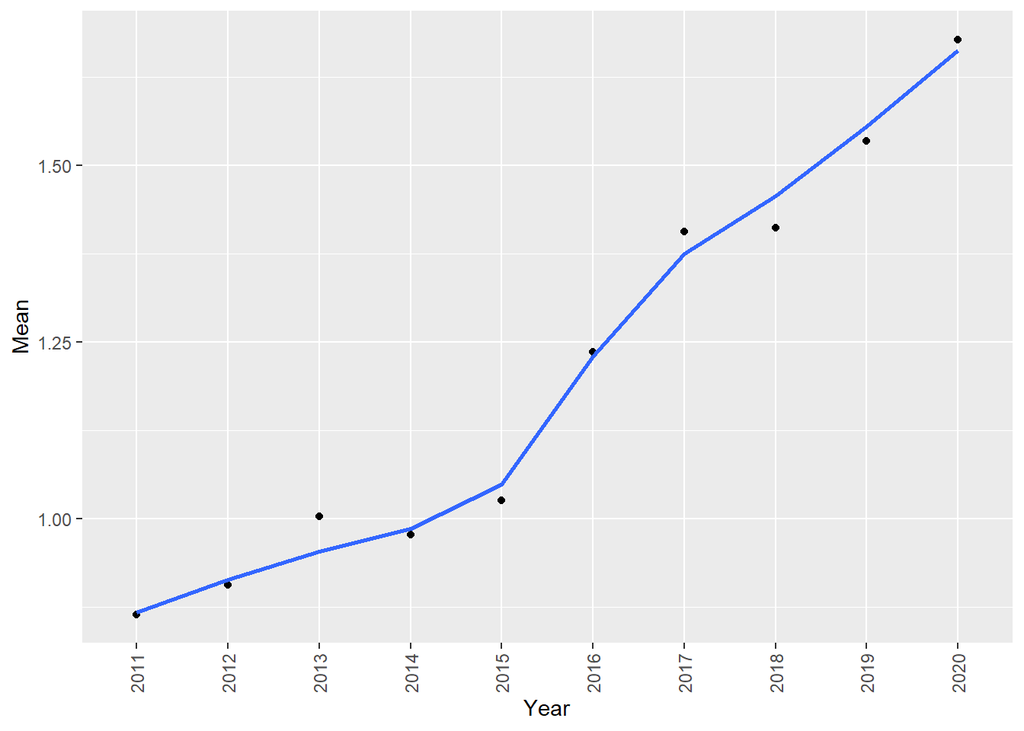

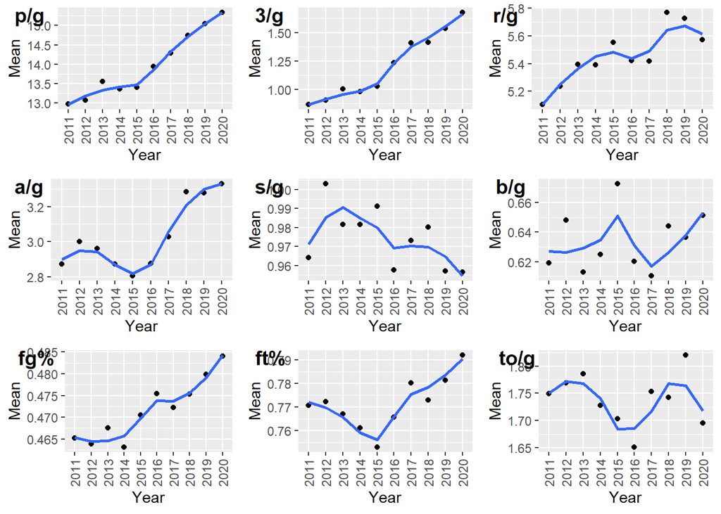

### Regression model

```
##
## Call:
## lm(formula = `p/g` ~ `3/g` + `r/g` + `to/g` + `fg%` + `ft%` +
##     `s/g` + `a/g`)
##
## Residuals:
##     Min      1Q  Median      3Q     Max
## -9.5579 -1.8293 -0.1868  1.5229 16.5796
##
## Coefficients:
##              Estimate Std. Error t value Pr(>|t|)
## (Intercept) -15.11809    1.01271 -14.928  < 2e-16 ***
## `3/g`         2.49083    0.08994  27.695  < 2e-16 ***
## `r/g`         0.47233    0.03481  13.569  < 2e-16 ***
## `to/g`        4.58618    0.14936  30.706  < 2e-16 ***
## `fg%`        16.49739    1.40949  11.705  < 2e-16 ***
## `ft%`        11.09076    0.77498  14.311  < 2e-16 ***
## `s/g`         0.42016    0.19553   2.149   0.0318 *
## `a/g`        -0.40221    0.05691  -7.068 2.21e-12 ***
## ---
## Signif. codes:  0 '***' 0.001 '**' 0.01 '*' 0.05 '.' 0.1 ' ' 1
##
## Residual standard error: 2.752 on 1872 degrees of freedom
## Multiple R-squared:  0.7318, Adjusted R-squared:  0.7308
## F-statistic: 729.8 on 7 and 1872 DF,  p-value: < 2.2e-16
```

From the scatterplots we can see that there exists some evidence of non-linear relationship between the response and the predictors, though not a lot. However, inter-predictor scatters are quite curvy, which will lead to problems with std. residuals analysis and unknown model misspecification. Also, some predictors seem very highly correlated among themselves. Let us recall the correlation matrix again:

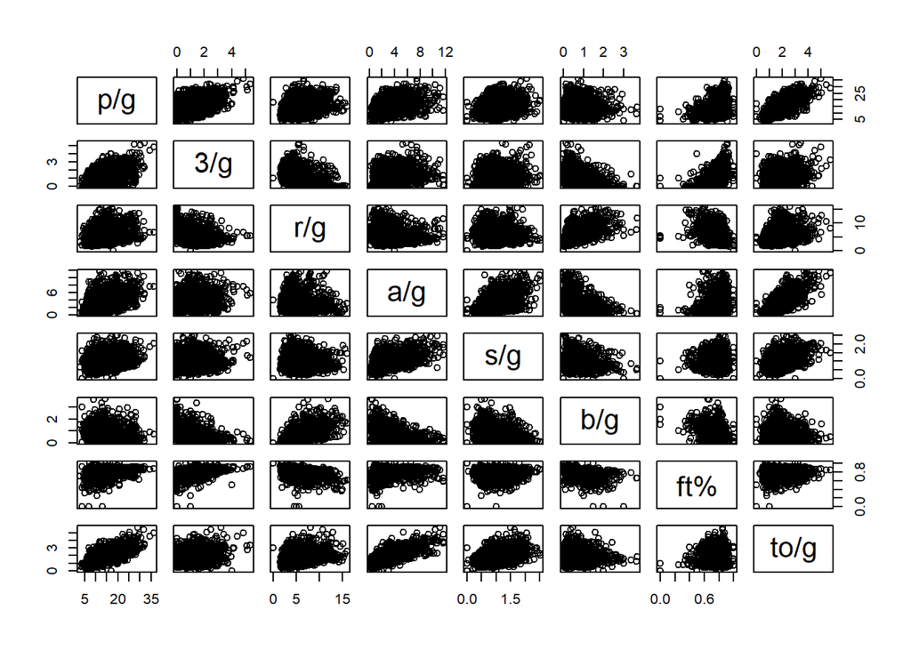

```
##             3/g        r/g       to/g        fg%        ft%        s/g
## 3/g   1.0000000 -0.4168977  0.2039304 -0.5398602  0.5129999  0.1950160
## r/g  -0.4168977  1.0000000  0.1921424  0.5145510 -0.3921333 -0.0683118
## to/g  0.2039304  0.1921424  1.0000000 -0.1215030  0.1438295  0.4687238
## fg%  -0.5398602  0.5145510 -0.1215030  1.0000000 -0.4486309 -0.2740825
## ft%   0.5129999 -0.3921333  0.1438295 -0.4486309  1.0000000  0.0578033
## s/g   0.1950160 -0.0683118  0.4687238 -0.2740825  0.0578033  1.0000000
## a/g   0.3002136 -0.1464473  0.7806362 -0.2812634  0.2276559  0.5422372
##             a/g
## 3/g   0.3002136
## r/g  -0.1464473
## to/g  0.7806362
## fg%  -0.2812634
## ft%   0.2276559
## s/g   0.5422372
## a/g   1.0000000
```

As suspected, we have there are some predictors with high correlation, such as “a/g” and “t/g”, and that might result in sort of multicollinearity. Let us look VIF:

```
##    `3/g`    `r/g`   `to/g`    `fg%`    `ft%`    `s/g`    `a/g`
## 1.713345 1.953627 3.578168 1.797872 1.525862 1.508020 3.600205
```

This shows that the predictors “to/g” and “a/g” are relatively poorly estimated compare to others, this also proves our analysis about the potential multicollinearity of the model. Lets then take a look at the standard diagnostic plots:

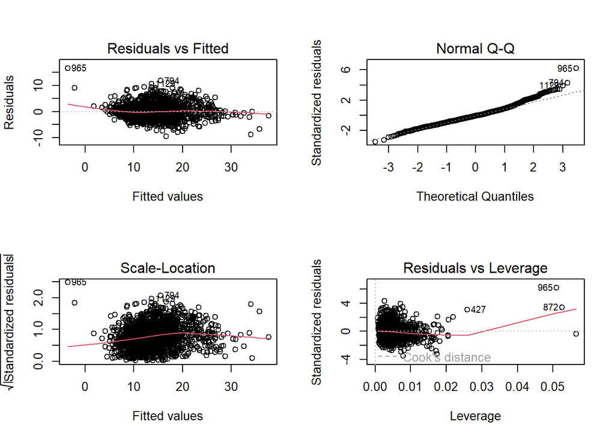

Normality of std. residuals is an issue and sq-root of std residuals do have a slight pattern, indicating this model might not be good enough. We should take a look at the std. residuals vs predictor plots:

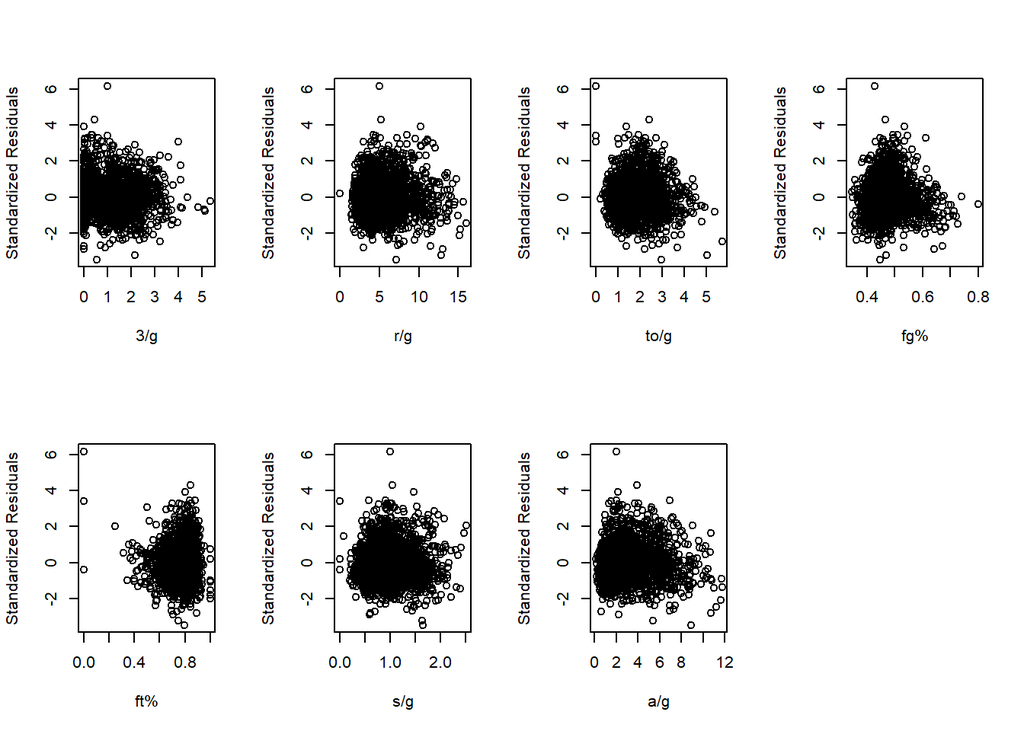

/Patterns seems not apparent for most predictors, but we have to say that ft% and 3/g present some evidence of curves. However, due to the big variation of player’s stats, outliers seem to be a really apparent. Overall, the model has a good performance in R-square value, and good significance on each variables, but poorly in outliers and leverage points with some high-correlation predictors that might lead to sort of multicollinearity.